# Practical Machine Learning Project

# Introduction

The goal of this project is to take data collected from motion sensors attached to the (upper) arm, forearm, belt, and dumbbell as a group of participants performed standard bicep curls.

Excerpt from HAR data website:

> Six young health participants were asked to perform one set of 10 repetitions of the Unilateral Dumbbell Biceps Curl in five different fashions:
- Exactly according to the specification (Class A)
- throwing the elbows to the front (Class B)
- lifting the dumbbell only halfway (Class C)
- lowering the dumbbell only halfway (Class D)
- throwing the hips to the front (Class E)

# Cross-validation approach

In order to generate a model that was appropriate to apply to the test data with unknown outcomes, a reasonable estimate of out-of-sample error should be generated. In order to estimate this out-of-sample error, I assume that the test data set would be well-approximated by a random sample of our training data. Thus, I partitioned the training data into a “training-training”" set and a “training-test”" set where the “training-training” set would be used to estimate my model that would then be applied to the “training-test” set to measure the out-of-sample accuracy of said model.

```r
library(caret)
library(dplyr)
```

```r
library(ggplot2)
library(randomForest)
setwd("C:/Users/USER/Dropbox/Coursera/Practical Machine Learning/Project")    #DESKTOP
train <- read.csv("pml-training.csv")
set.seed(12321)
inTrain <- createDataPartition(train$classe, p = .5, list=FALSE) # Lower size of training set to make the
                                                                 # train() call go faster
train.train <- train[inTrain,]
train.test <- train[-inTrain,]
```

# Selection of Predictors

The first thing that was done was to clear out variables with lots of NAs or missing values, e.g.:

```r
summary(train$var_yaw_arm)
```

```
##      Min.   1st Qu.    Median      Mean   3rd Qu.      Max.      NA's
##     0.000     6.642   278.300  1056.000  1295.000 31340.000     19216
```

The following code removes those troublesome predictors:

```r
#Clean out the columns with large numbers of NAs and missing data and useless stuff
train.clean <- train.train[,-which(is.na(train[1,]))]       #NAs
train.clean <- train.clean[,-which(train.clean[1,] == "")]  #Blanks
train.clean <- train.clean[,-c(1:7)]                     #Useless stuff
```

Next, there were some other predictors that appears particularly unexciting as they didn’t offer very much variation between the different bicep classifications. These were all labeled “total_accel_[blank]”.

[output not shown]

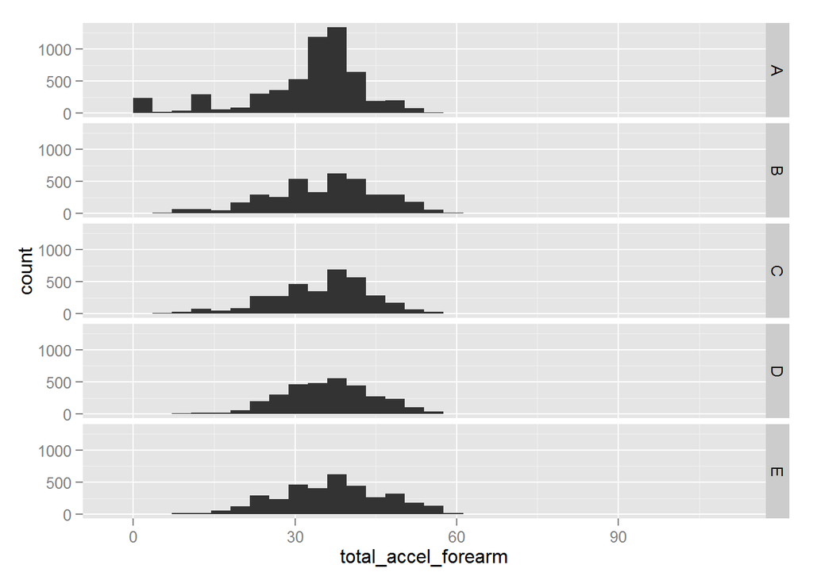

```r
qplot(total_accel_forearm, data = train, facets = classe~.)
```

```r
train.clean <- train.clean %>%
            dplyr::select(c(-total_accel_arm,
                            -total_accel_dumbbell,
                            -total_accel_forearm,
                            -total_accel_belt))
```

This leaves us with 48 predictors and 1 outcome variable left in the data frame that will be used to train our model, named train.clean:

```r
ncol(train.clean)
```

```
## [1] 49
```

# Training the model

The caret package comes loaded with a large selection of different algorithms that can be used in training one’s model; after trying out many of them, the approach that offered the best accuracy without taking a huge amount of computation time was the random forest approach. Methods that I tried before this were not able to even generate an in-sample accuracy above 70% but random forests offered accuracy over 99%, which was more than enough to predict the test set, the overall goal of this project. It is worth mentioning that for the random forests methodology, cross-validation is unnecessary for valid estimation of the test set error. I went ahead retained the above partition and double checked just for the sake of completeness; the fact that partitioning makes the calculations complete much more quickly also helps.

```r
predModel<-train(classe~.,data=train.clean,method="rf",
                trControl=trainControl(method="oob")) #out of bag error estimates, unbiased
print(predModel)
```

```
## Random Forest
##
## 9812 samples
##   48 predictor
##    5 classes: 'A', 'B', 'C', 'D', 'E'
##
## No pre-processing
## Resampling results across tuning parameters:
##
##   mtry  Accuracy   Kappa
##    2    0.9919486  0.9898141
##   25    0.9894007  0.9865922
##   48    0.9846107  0.9805309
##
## Accuracy was used to select the optimal model using  the largest value.
## The final value used for the model was mtry = 2.
```

# Out of sample error rate

If we apply this model to the partitioned data set aside earlier on as train.test, we have an estimate of the out-of-sample accuracy. The following takes the number of times that the model correctly predicts the outcome and divides by the total number of observations:

```r
accuracy <- sum(predict(predModel, train.test)==train.test$classe)/nrow(train.test)
print(accuracy)
```

```
## [1] 0.9878695
```

You can see that the accuracy is slightly lower than the in-sample accuracy from above but not much lower (98.8% compared to 99.2%). We deem this to be sufficiently accurate to take to the separate test set to estimate outcomes that are unknown.

# Predicting outcomes on the test set

```r
test <- read.csv("pml-testing.csv")
test.clean <- test[,-which(is.na(test[1,]))]
test.clean <- test.clean[,-c(1:7)]
test.clean <- test.clean %>%
      dplyr::select(c(-total_accel_arm,
                      -total_accel_dumbbell,
                      -total_accel_forearm,
                      -total_accel_belt))

predictedOutcomes <- predict(predModel, test.clean)
```

When these were submitted, they were all correct, so it seems as though this approach was successful!

# Appendix

Just for fun, the same thing as above was done using a gradient boosting method instead of random forests:

```r
predModel.v2<-train(classe~.,data=train.clean,method="gbm", verbose = FALSE)
accuracy.v2 <- sum(predict(predModel.v2, train.test)==train.test$classe)/nrow(train.test)
print(accuracy.v2)
```

```
## [1] 0.9573904
```